# Hurdle Modelling

Author

Babak Naimi

## Amphibians

Here, we run the models for 3 amphibian datasets and save the modelling object and other relevant results/interpretation in the working directory:

## Loading libraries and Reading Data

```r
library(glmmTMB)
library(DHARMa)
library(performance)
library(dplyr)
library(purrr)
library(tidyr)
library(readr)
library(splines)
library(ggplot2)
library(ape)
library(mgcv)
library(mice)
library(sdm)
library(brms)
#--------------------

.model_update <- FALSE # this is a global variabl, if FALSE and models are saved already, they are loaded, If, TRUE, models are fitted again even if available
```

```r
# Loading functions:
source('Functions_.R')

dat_all <- read.csv("../outputs/tables/amph_all_dat.csv")
dat_byprod <- read.csv("../outputs/tables/amph_byprod_dat.csv")
dat_live <- read.csv("../outputs/tables/amph_live_dat.csv")

# reading phylogenetic tree dataset for amphibians
phy <- ape::read.tree("../data/phylogeny/amphibians/amph_shl_new_Consensus_7238.tre")

# For amphibians, to fix new/old scientific names mismatch between phy and dat!
phy$tip.label[1388] <- "Paruwrobates_erythromos"
phy$tip.label[4056] <- "Sclerophrys_superciliaris"
#------------
# reading data:
.dat_all <- .getData(dat_all,phy,spn='Species',yn='Year',response = 'Trade',impute = F,scalelog = 'all')

.dat_byprod <- .getData(dat_byprod,phy,spn='Species',yn='Year',response = 'Trade',impute = F,scalelog = 'all')

.dat_live <- .getData(dat_live,phy,spn='Species',yn='Year',response = 'Trade',impute = F,scalelog = 'all')
```

### **Screening which variables should be included (linear or time-varying)**

Here, all the variables are tested individually to identify useful variables and their form of relationship (linear or flexible or time-varying):

```r
#====
scr_all <- trait_screening(.dat_all)
```

```
Overdispersion ~ 1478.00 → NB.
```

```r
scr_live <- trait_screening(.dat_live)
```

```
Overdispersion ~ 1024.65 → NB.
```

```r
scr_byprod <- trait_screening(.dat_byprod,k_year = 4,k_cont = 4,min_pos = 5,
                              gamma_pen = 1)
```

```
Overdispersion ~ 88728299.60 → NB.
```

```r
#-------

# screening results for amphibian_all:

scr_all
```

```
# A tibble: 14 × 6
   variable        component choice               delta_AIC   edf keep
   <chr>           <chr>     <chr>                    <dbl> <dbl> <lgl>
 1 RangeAvailable  count     timevarying(poisson)   70.2    18.7  TRUE
 2 IUCN_Status     count     timevarying(poisson)   44.6    11.2  TRUE
 3 Habits          count     timevarying(poisson)   32.9     9.60 TRUE
 4 BrightColours   count     timevarying(poisson)    4.06   11.5  TRUE
 5 SnoutVentLength count     timevarying(poisson)    2.31   12.0  TRUE
 6 Poison          count     timevarying(poisson)    1.21   11.0  FALSE
 7 Development     count     timevarying(poisson)    0.0384 11.2  FALSE
 8 IUCN_Status     zero      timevarying            18.4    17.9  TRUE
 9 RangeAvailable  zero      timevarying            11.5    17.9  TRUE
10 BrightColours   zero      timevarying             6.57   17.2  TRUE
11 Habits          zero      linear                  3.11   16.2  TRUE
12 SnoutVentLength zero      linear                  1.48   18.1  FALSE
13 Development     zero      timevarying             1.20   18.6  FALSE
14 Poison          zero      linear                  1.17   18.0  FALSE
```

```r
# screening results for amphibian_byprod:

scr_byprod
```

```
# A tibble: 12 × 6
   variable        component choice                 delta_AIC   edf keep
   <chr>           <chr>     <chr>                      <dbl> <dbl> <lgl>
 1 IUCN_Status     count     timevarying(poisson) 22.4         2.00 TRUE
 2 RangeAvailable  count     timevarying(poisson)  1.76        2.47 FALSE
 3 Habits          count     linear(poisson)       0.233       1.98 FALSE
 4 SnoutVentLength count     timevarying(poisson) -0.0547      2.82 FALSE
 5 Poison          count     linear(poisson)      -5.39        1.92 FALSE
 6 IUCN_Status     zero      timevarying          15.3         3.79 TRUE
 7 Habits          zero      linear                1.59        1.87 FALSE
 8 SnoutVentLength zero      timevarying           1.25        3.17 FALSE
 9 BrightColours   zero      timevarying           0.411       2.77 FALSE
10 RangeAvailable  zero      smooth               -0.00000365  3.40 FALSE
11 Development     zero      timevarying          -0.704       3.39 FALSE
12 Poison          zero      linear               -1.31        3.55 FALSE
```

```r
# screening results for amphibian_live:

scr_live
```

```
# A tibble: 14 × 6
   variable        component choice               delta_AIC   edf keep
   <chr>           <chr>     <chr>                    <dbl> <dbl> <lgl>
 1 RangeAvailable  count     timevarying(poisson)   50.9    19.0  TRUE
 2 IUCN_Status     count     timevarying(poisson)   26.1    10.7  TRUE
 3 Habits          count     timevarying(poisson)   16.6     9.24 TRUE
 4 BrightColours   count     timevarying(poisson)    3.66   11.6  TRUE
 5 Poison          count     linear(poisson)        -0.0355 11.3  FALSE
 6 Development     count     timevarying(poisson)   -0.0431 11.4  FALSE
 7 SnoutVentLength count     linear(poisson)        -0.298  11.3  FALSE
 8 IUCN_Status     zero      timevarying            19.0    17.8  TRUE
 9 RangeAvailable  zero      timevarying            12.4    17.7  TRUE
10 BrightColours   zero      timevarying             6.89   17.2  TRUE
11 Habits          zero      linear                  3.09   16.2  TRUE
12 SnoutVentLength zero      linear                  1.47   18.1  FALSE
13 Poison          zero      linear                  1.19   18.0  FALSE
14 Development     zero      timevarying             1.17   18.5  FALSE
```

## Modelling (glmmTMB)

Fit models based on glmmTMB. We save the model object and here, the model is loaded if it was saved before (unless the global variable .model_update is turned to TRUE and the beginning of the document, which models are fitted again).

```r
.eps <- list(R2= 0.05,
             MSE= 0,
             cor_truth = 0.05,
             cor_pred = 0.05,
             brier_zero = 0)

# formula generated based on the screening results + sample size
fml_all <- .get_terms_glmmTMB(.dat_all,scr_all,EPV_zero = 10, PP_count = 12)

if (!file.exists('_results/amph/models/model_glmm_amph_all.rds') || .model_update) {
  m_all <- fit_hurdle_glmmTMB(.dat_all,fml_all,phylo_in = 'count')
  .ms <- simplify_Model(m_all,scr = scr_all,.dat = .dat_all,rank = 'perm', .which = 'both',drop = T,eps = .eps)
  m_all <- .ms$model
  scr_all <- .ms$screening
  if (m_all$sdr$pdHess) {
    saveRDS(m_all,'_results/amph/models/model_glmm_amph_all.rds')
    write_csv(scr_all,'_results/amph/others/screening_all.csv')
    cat('\n Model for amph_all is saved...!')
  } else cat('\n Model for amph_all is NOT CONVERGED....!\n')
} else {
  m_all <- readRDS('_results/amph/models/model_glmm_amph_all.rds')
  scr_all <- read_csv('_results/amph/others/screening_all.csv')
}
#----


fml_byprod <- .get_terms_glmmTMB(.dat_byprod,scr_byprod,EPV_zero = 10, PP_count = 12)

if (!file.exists('_results/amph/models/model_glmm_amph_byprod.rds') || .model_update) {
  m_byprod <- fit_hurdle_glmmTMB(.dat_byprod,fml_byprod,phylo_in = 'count')
  .ms <- simplify_Model(m_byprod,scr = scr_byprod,.dat = .dat_byprod,rank = 'perm', .which = 'both',drop = T,eps = .eps)
  m_byprod <- .ms$model
  scr_byprod <- .ms$screening
  if (m_byprod$sdr$pdHess) {
    saveRDS(m_byprod,'_results/amph/models/model_glmm_amph_byprod.rds')
    write_csv(scr_byprod,'_results/amph/others/screening_byprod.csv')
    cat('\n Model for amph_byprod is saved...!')
  } else cat('\n Model for amph_byprod is NOT CONVERGED....!\n')
} else {
  m_byprod <- readRDS('_results/amph/models/model_glmm_amph_byprod.rds')
  scr_byprod <- read_csv('_results/amph/others/screening_byprod.csv')
}
#----

fml_live <- .get_terms_glmmTMB(.dat_live,scr_live,EPV_zero = 10, PP_count = 12)

if (!file.exists('_results/amph/models/model_glmm_amph_live.rds') || .model_update) {
  m_live <- fit_hurdle_glmmTMB(.dat_live,fml_live,phylo_in = 'count')
  .ms <- simplify_Model(m_live,scr = scr_live,.dat = .dat_live,rank = 'perm', .which = 'both',drop = T,eps = .eps)
  m_live <- .ms$model
  scr_live <- .ms$screening
  if (m_live$sdr$pdHess) {
    saveRDS(m_live,'_results/amph/models/model_glmm_amph_live.rds')
    write_csv(scr_live,'_results/amph/others/screening_live.csv')
    cat('\n Model for amph_live is saved...!')
  } else cat('\n Model for amph_live is NOT CONVERGED....!\n')
} else {
  m_live <- readRDS('_results/amph/models/model_glmm_amph_live.rds')
  scr_live <- read_csv('_results/amph/others/screening_live.csv')
}
#----
```

## Model Performance & Summary information

```r
# amph_all:
cat('\n Results for Amphibians_all:')
```

```
 Results for Amphibians_all:
```

```r
# Model Statistics:
check_model_full(m_all,.dat = .dat_all)
```

```
$pdHess
[1] TRUE

$R2_overall_marginal
[1] 0.6447044

$R2_overall_conditional
[1] 0.6447044

$zero
$zero$n
[1] 528

$zero$brier
[1] 0.09814616

$zero$brier_null
[1] 0.196611

$zero$R2_brier
[1] 0.5008104

$zero$logloss
[1] 0.3222549

$zero$logloss_null
[1] 0.5822011

$zero$R2_logloss
[1] 0.4464886

$zero$AUC
[1] 0.912


$count
$count$n_pos
[1] 142

$count$RMSE
[1] 2357.785

$count$R2_efron
[1] 0.6466049

$count$R2_cor2
[1] 0.6930802

$count$R2_LL
[1] 0.1534117
```

```r
# summary:
summary(m_all)
```

```
 Family: truncated_nbinom2  ( log )
Formula:
Trade ~ ns(Year_c, df = 4) + ns(Year_c, df = 4):RangeAvailable +
    RangeAvailable + ns(Year_c, df = 4):IUCN_Status + IUCN_Status +
    Habits + BrightColours + propto(0 + Species | dummy, A)
Zero inflation:
~ns(Year_c, df = 5) + ns(Year_c, df = 5):IUCN_Status + IUCN_Status +
    RangeAvailable + BrightColours + Habits
Data: dat

      AIC       BIC    logLik -2*log(L)  df.resid
   2399.7    2561.9   -1161.8    2323.7       490

Random effects:

Conditional model:
 Groups Name                                Variance Std.Dev.
 dummy  SpeciesAgalychnis_lemur             5e-08    0.0002236
        SpeciesAllobates_femoralis          5e-08    0.0002236
        SpeciesAllobates_myersi             5e-08    0.0002236
        SpeciesAllobates_zaparo             5e-08    0.0002236
        SpeciesAmbystoma_dumerilii          5e-08    0.0002236
        SpeciesAmbystoma_mexicanum          5e-08    0.0002236
        SpeciesCalyptocephalella_gayi       5e-08    0.0002236
        SpeciesCryptobranchus_alleganiensis 5e-08    0.0002236
        SpeciesDyscophus_antongilii         5e-08    0.0002236
        SpeciesDyscophus_guineti            5e-08    0.0002236
        ...                                 ...      ...












```

[output cut: 135 more lines]

```
ns(Year_c, df = 5)4
ns(Year_c, df = 5)5
IUCN_StatusThreatened
RangeAvailable                            **
BrightColoursYes                          ***
HabitsTer
HabitsTerAq                               **
HabitsTerArb                              **
ns(Year_c, df = 5)1:IUCN_StatusThreatened
ns(Year_c, df = 5)2:IUCN_StatusThreatened
ns(Year_c, df = 5)3:IUCN_StatusThreatened
ns(Year_c, df = 5)4:IUCN_StatusThreatened
ns(Year_c, df = 5)5:IUCN_StatusThreatened
---
Signif. codes:  0 '***' 0.001 '**' 0.01 '*' 0.05 '.' 0.1 ' ' 1
```

```
qu = 0.25, log(sigma) = -2.137114 : outer Newton did not converge fully.
```

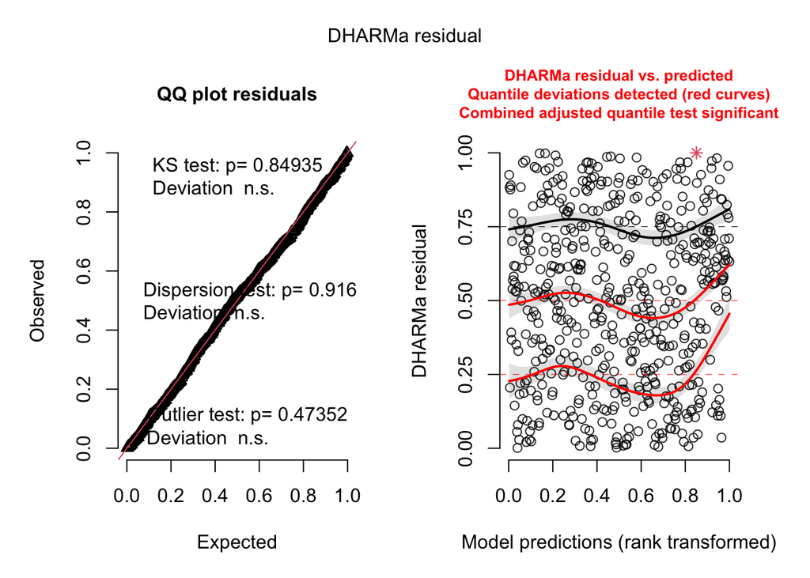

```r
sim <- DHARMa::simulateResiduals(m_all,n=500,plot=T)
```

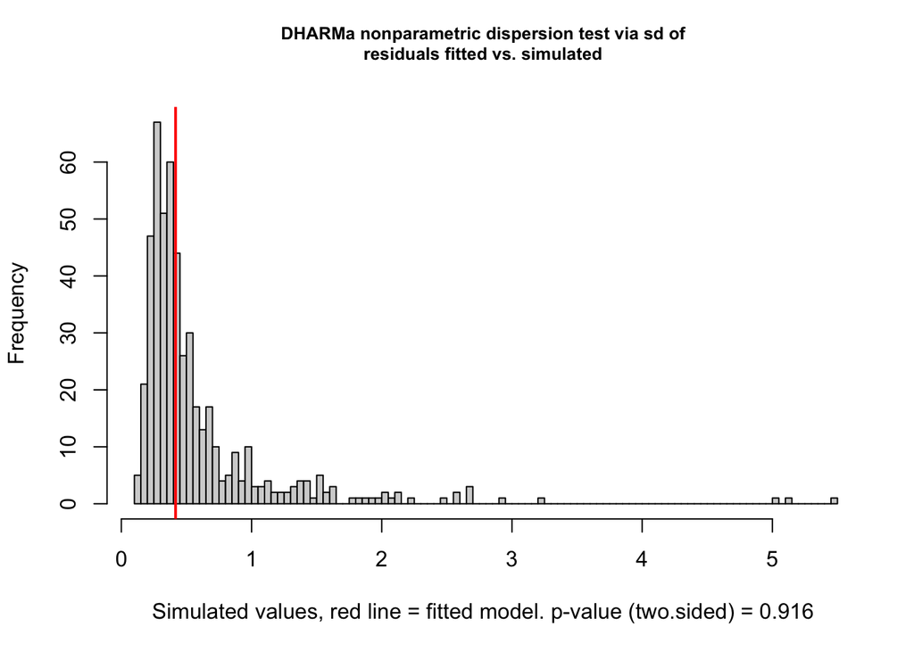

```
    DHARMa nonparametric dispersion test via sd of residuals fitted vs.
    simulated

data:  simulationOutput
dispersion = 0.70876, p-value = 0.916
alternative hypothesis: two.sided
```

```r
# test Dispersion:
testDispersion(sim)
```

```r
#amph_byprod:

cat('\n Results for Amphibians_byprod:')
```

```
 Results for Amphibians_byprod:
```

```r
# Model Statistics:
check_model_full(m_byprod,.dat = .dat_byprod)
```

```
$pdHess
[1] TRUE

$R2_overall_marginal
[1] -0.709245

$R2_overall_conditional
[1] -0.709245

$zero
$zero$n
[1] 528

$zero$brier
[1] 0.01429075

$zero$brier_null
[1] 0.01492195

$zero$R2_brier
[1] 0.04230023

$zero$logloss
[1] 0.0657207

$zero$logloss_null
[1] 0.07851576

$zero$R2_logloss
[1] 0.1629618

$zero$AUC
[1] 0.821


$count
$count$n_pos
[1] 8

$count$RMSE
[1] 646.5481

$count$R2_efron
[1] 0.2278111

$count$R2_cor2
[1] 0.7494405

$count$R2_LL
[1] 0.3724174
```

```r
# summary:
summary(m_byprod)
```

```
 Family: truncated_nbinom2  ( log )
Formula:
Trade ~ ns(Year_c, df = 3) + IUCN_Status + propto(0 + Species |      dummy, A)
Zero inflation:         ~ns(Year_c, df = 5) + IUCN_Status
Data: dat

      AIC       BIC    logLik -2*log(L)  df.resid
    178.2     238.0     -75.1     150.2       514

Random effects:

Conditional model:
 Groups Name                                Variance  Std.Dev.
 dummy  SpeciesAgalychnis_lemur             3.664e-14 1.914e-07
        SpeciesAllobates_femoralis          3.664e-14 1.914e-07
        SpeciesAllobates_myersi             3.664e-14 1.914e-07
        SpeciesAllobates_zaparo             3.664e-14 1.914e-07
        SpeciesAmbystoma_dumerilii          3.664e-14 1.914e-07
        SpeciesAmbystoma_mexicanum          3.664e-14 1.914e-07
        SpeciesCalyptocephalella_gayi       3.664e-14 1.914e-07
        SpeciesCryptobranchus_alleganiensis 3.664e-14 1.914e-07
        SpeciesDyscophus_antongilii         3.664e-14 1.914e-07
        SpeciesDyscophus_guineti            3.664e-14 1.914e-07
        ...                                 ...       ...
















```

[output cut: 67 more lines]

```
ns(Year_c, df = 3)2    243.492     69.943   3.481 0.000499 ***
ns(Year_c, df = 3)3     33.533     10.410   3.221 0.001276 **
IUCN_StatusThreatened    2.244      1.146   1.957 0.050322 .
---
Signif. codes:  0 '***' 0.001 '**' 0.01 '*' 0.05 '.' 0.1 ' ' 1

Zero-inflation model:
                      Estimate Std. Error z value Pr(>|z|)
(Intercept)            43.6628    28.6271   1.525    0.127
ns(Year_c, df = 5)1   -37.7476    26.7606  -1.411    0.158
ns(Year_c, df = 5)2   -38.3414    29.8474  -1.285    0.199
ns(Year_c, df = 5)3   -27.7915    19.4675  -1.428    0.153
ns(Year_c, df = 5)4   -75.4015    57.7998  -1.304    0.192
ns(Year_c, df = 5)5    -4.7715    13.8195  -0.345    0.730
IUCN_StatusThreatened  -0.2410     0.7369  -0.327    0.744
```

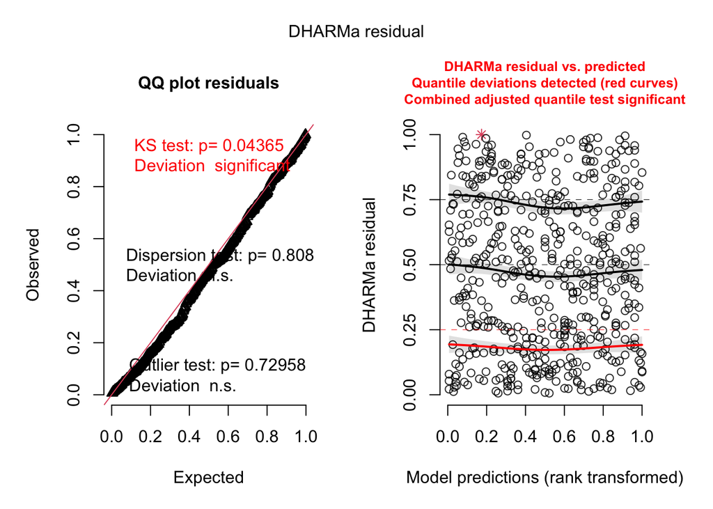

```r
sim <- DHARMa::simulateResiduals(m_byprod,n=500,plot=T)
```

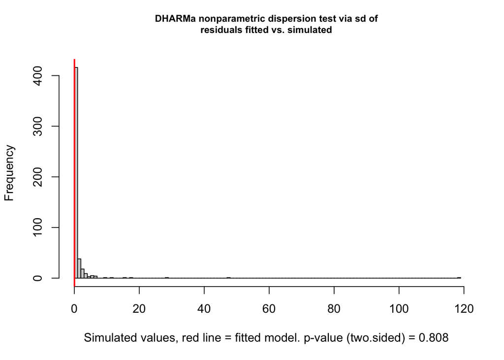

```
    DHARMa nonparametric dispersion test via sd of residuals fitted vs.
    simulated

data:  simulationOutput
dispersion = 0.035004, p-value = 0.808
alternative hypothesis: two.sided
```

```r
# test Dispersion:
testDispersion(sim)
```

```r
# amph_live:

cat('\n Results for Amphibians_live:')
```

```
 Results for Amphibians_live:
```

```r
# Model Statistics:
check_model_full(m_live,.dat = .dat_live)
```

```
$pdHess
[1] TRUE

$R2_overall_marginal
[1] 0.6442754

$R2_overall_conditional
[1] 0.6442754

$zero
$zero$n
[1] 528

$zero$brier
[1] 0.08989352

$zero$brier_null
[1] 0.1930527

$zero$R2_brier
[1] 0.5343576

$zero$logloss
[1] 0.2959447

$zero$logloss_null
[1] 0.5744784

$zero$R2_logloss
[1] 0.4848463

$zero$AUC
[1] 0.924


$count
$count$n_pos
[1] 138

$count$RMSE
[1] 2797.046

$count$R2_efron
[1] 0.5113367

$count$R2_cor2
[1] 0.5116888

$count$R2_LL
[1] 0.1631149
```

```r
# summary:
summary(m_live)
```

```
 Family: truncated_nbinom2  ( log )
Formula:
Trade ~ ns(Year_c, df = 4) + ns(Year_c, df = 4):RangeAvailable +
    RangeAvailable + ns(Year_c, df = 4):IUCN_Status + IUCN_Status +
    Habits + BrightColours + propto(0 + Species | dummy, A)
Zero inflation:
~ns(Year_c, df = 5) + ns(Year_c, df = 5):IUCN_Status + IUCN_Status +
    ns(Year_c, df = 5):RangeAvailable + RangeAvailable + BrightColours +
    Habits
Data: dat

      AIC       BIC    logLik -2*log(L)  df.resid
   2333.4    2517.0   -1123.7    2247.4       485

Random effects:

Conditional model:
 Groups Name                                Variance  Std.Dev.
 dummy  SpeciesAgalychnis_lemur             9.127e-09 9.554e-05
        SpeciesAllobates_femoralis          9.127e-09 9.554e-05
        SpeciesAllobates_myersi             9.127e-09 9.554e-05
        SpeciesAllobates_zaparo             9.127e-09 9.554e-05
        SpeciesAmbystoma_dumerilii          9.127e-09 9.554e-05
        SpeciesAmbystoma_mexicanum          9.127e-09 9.554e-05
        SpeciesCalyptocephalella_gayi       9.127e-09 9.554e-05
        SpeciesCryptobranchus_alleganiensis 9.127e-09 9.554e-05
        SpeciesDyscophus_antongilii         9.127e-09 9.554e-05
        SpeciesDyscophus_guineti            9.127e-09 9.554e-05
        ...                                 ...       ...











```

[output cut: 146 more lines]

```
HabitsTer
HabitsTerAq                               *
HabitsTerArb                              *
ns(Year_c, df = 5)1:IUCN_StatusThreatened
ns(Year_c, df = 5)2:IUCN_StatusThreatened
ns(Year_c, df = 5)3:IUCN_StatusThreatened
ns(Year_c, df = 5)4:IUCN_StatusThreatened
ns(Year_c, df = 5)5:IUCN_StatusThreatened
ns(Year_c, df = 5)1:RangeAvailable
ns(Year_c, df = 5)2:RangeAvailable
ns(Year_c, df = 5)3:RangeAvailable
ns(Year_c, df = 5)4:RangeAvailable
ns(Year_c, df = 5)5:RangeAvailable
---
Signif. codes:  0 '***' 0.001 '**' 0.01 '*' 0.05 '.' 0.1 ' ' 1
```

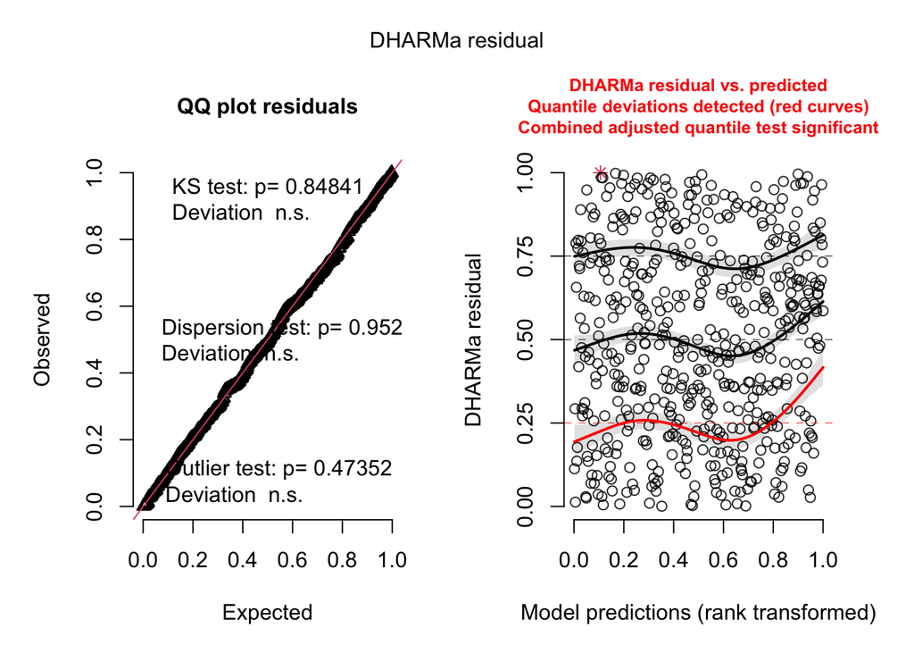

```r
sim <- DHARMa::simulateResiduals(m_live,n=500,plot=T)
```

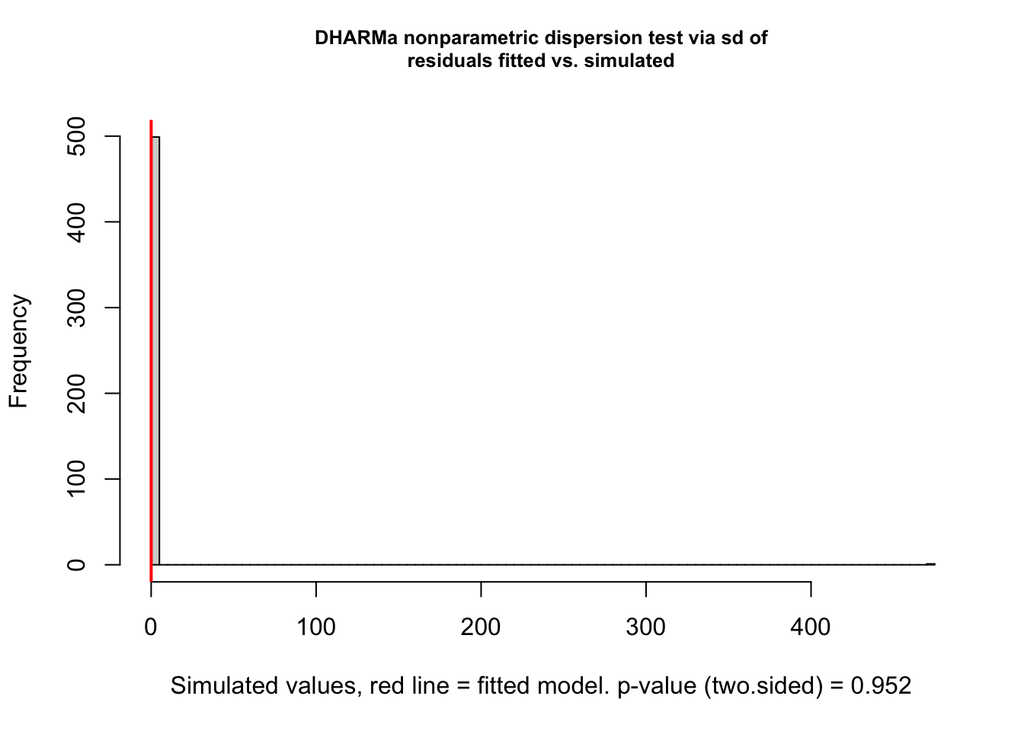

```
    DHARMa nonparametric dispersion test via sd of residuals fitted vs.
    simulated

data:  simulationOutput
dispersion = 0.015766, p-value = 0.952
alternative hypothesis: two.sided
```

```r
# test Dispersion:
testDispersion(sim)
```

## Relative Importance of Traits

Here, we measure a relative importance using permutation test and given multiple metrics. We then combine them (mean) to get a final assessment:

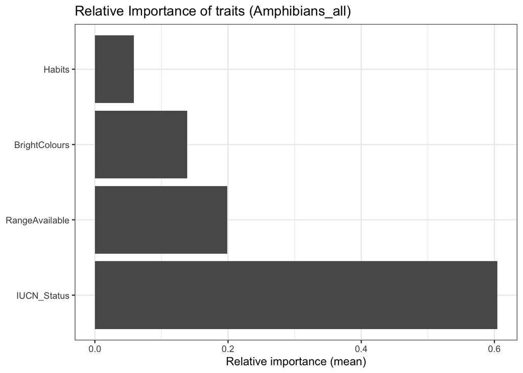

```r
imp_perm_all <- score_traits_perm_glmmTMB(m_all,.dat_all,
                                          vars = unique(scr_all$variable),
                                      metrics = c("R2","MSE","cor_truth","cor_pred","brier_zero"),
                                      nrep   = 10,re.form = NULL)


imp_perm_byprod <- score_traits_perm_glmmTMB(m_byprod,.dat_byprod,
                                          vars = unique(scr_byprod$variable),
                                      metrics = c("R2","MSE","cor_truth","cor_pred","brier_zero"),
                                      nrep   = 10,re.form = NULL)

imp_perm_live <- score_traits_perm_glmmTMB(m_live,.dat_live,
                                          vars = unique(scr_live$variable),
                                      metrics = c("R2","MSE","cor_truth","cor_pred","brier_zero"),
                                      nrep   = 10,re.form = NULL)

#-----------

plot_perm_importance(imp_perm_all,metric = 'mean',title='Relative Importance of traits (Amphibians_all)')
```

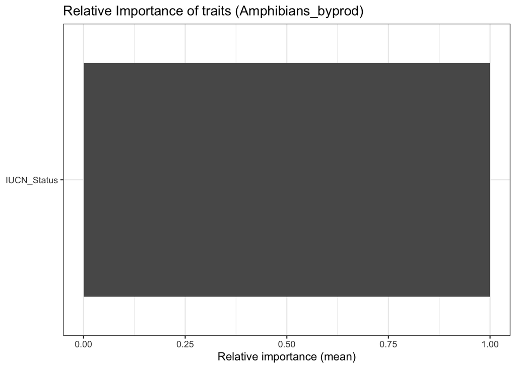

```r
ggsave('_results/amph/plots/trait_importance_amph_all.png')
plot_perm_importance(imp_perm_byprod,metric = 'mean',title='Relative Importance of traits (Amphibians_byprod)')
```

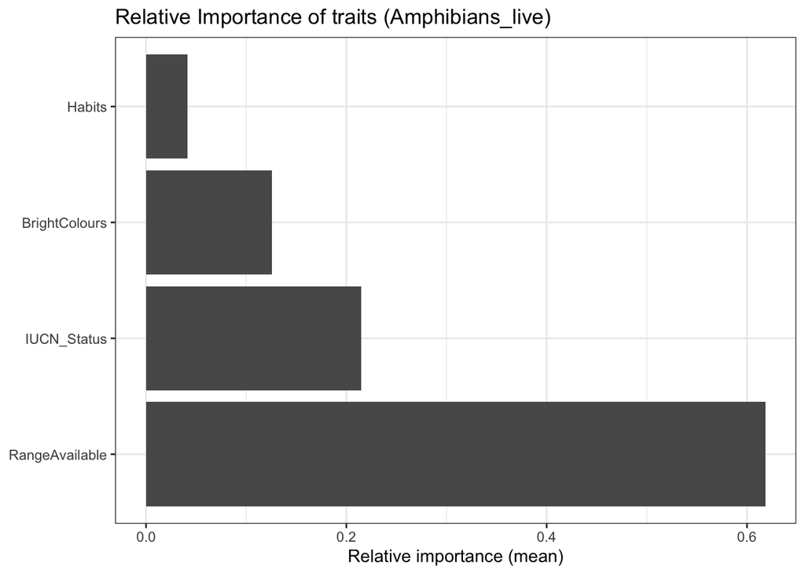

```r
ggsave('_results/amph/plots/trait_importance_amph_byprod.png')
plot_perm_importance(imp_perm_live,metric = 'mean',title='Relative Importance of traits (Amphibians_live)')
```

```r
ggsave('_results/amph/plots/trait_importance_amph_live.png')
```

## Time-varying plots

Conditional effects

```
 Plotting Time-varying plots for numeric traits based on Amphibians_all dataset:
```

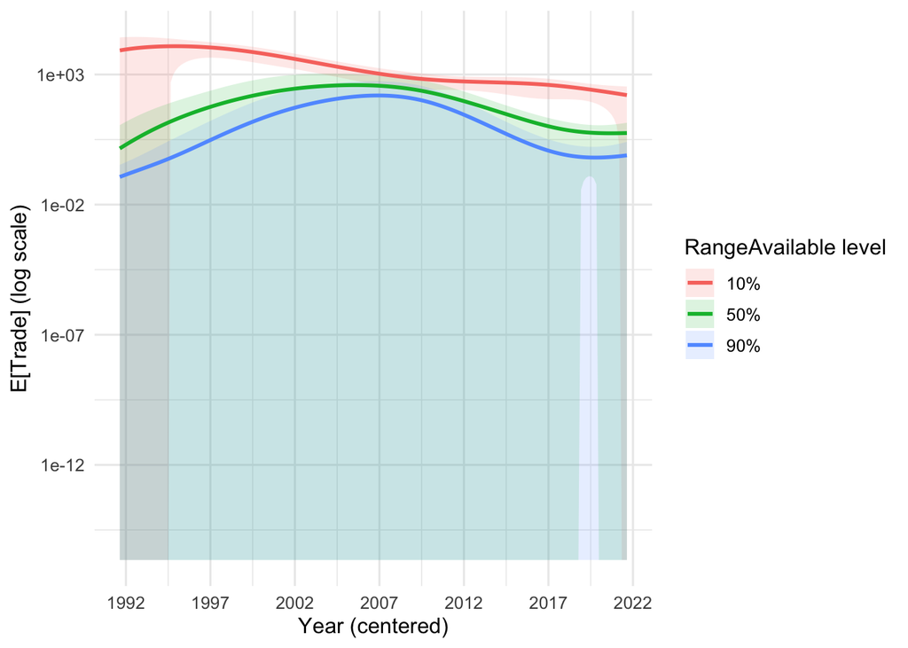

```r
scr <- scr_all

traits <- unique(scr$variable[scr$keep])

ntraits <- traits[traits %in% .dat_all$vars_numeric] # numeric traits
ntraits <- unique(scr$variable[scr$variable %in% ntraits & grepl('timevarying',scr$choice)])


if (length(ntraits) > 0) {
  cat('\n Plotting Time-varying plots for numeric traits based on Amphibians_all dataset:\n')
  for (n in ntraits) {
    p1 <- plot_tvc(m_all, .dat_all$data, focal = n, by_quantiles = c(.1,.5,.9),
                   year_scale = .dat_all$scaler$Year,year_lim = c(1992,2022),nticks = 6)
    print(p1)
    ggsave(paste0('_results/amph/plots/tvc_amph_all__',n,'.png'))
  }
}
```

```
 Plotting Time-varying plots for numeric traits based on Amphibians_live dataset:
```

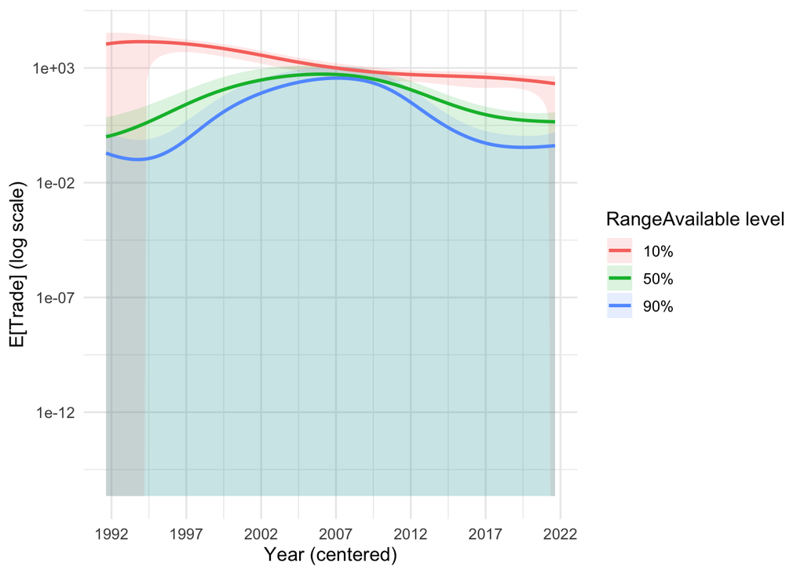

```r
#===================

scr <- scr_byprod

traits <- unique(scr$variable[scr$keep])

ntraits <- traits[traits %in% .dat_byprod$vars_numeric]
ntraits <- unique(scr$variable[scr$variable %in% ntraits & grepl('timevarying',scr$choice)])


if (length(ntraits) > 0) {
  cat('\n Plotting Time-varying plots for numeric traits based on Amphibians_byprod dataset:\n')
  for (n in ntraits) {
    p1 <- plot_tvc(m_byprod, .dat_byprod$data, focal = n, by_quantiles = c(.1,.5,.9),
                   year_scale = .dat_byprod$scaler$Year,year_lim = c(1992,2022),nticks = 6)
    print(p1)
    ggsave(paste0('_results/amph/plots/tvc_amph_byprod__',n,'.png'))
  }
}
#===================

scr <- scr_live

traits <- unique(scr$variable[scr$keep])

ntraits <- traits[traits %in% .dat_live$vars_numeric] # numeric traits
ntraits <- unique(scr$variable[scr$variable %in% ntraits & grepl('timevarying',scr$choice)])


if (length(ntraits) > 0) {
  cat('\n Plotting Time-varying plots for numeric traits based on Amphibians_live dataset:\n')
  for (n in ntraits) {
    p1 <- plot_tvc(m_live, .dat_live$data, focal = n, by_quantiles = c(.1,.5,.9),
                   year_scale = .dat_live$scaler$Year,year_lim = c(1992,2022),nticks = 6)
    print(p1)
    ggsave(paste0('_results/amph/plots/tvc_amph_live__',n,'.png'))
  }
}
```

```r
#===================
```

## More interpretation

Additional plots for interpreting the role of traits

```r
# Wald test for Cond/Zi parts:

cat('\n Amphinian_all:')
```

```
 Amphinian_all:
```

```r
traits_count <- unique(scr_all$variable[scr_all$keep & scr_all$component == 'count'])
traits_zi <- unique(scr_all$variable[scr_all$keep & scr_all$component == 'zero'])

imp <- plot_trait_importance_glmmTMB(m_all, .dat_all,traits = traits_count,
                                          method = "wald", component = "cond")
imp$table
```

```
  component                              term     Chisq Df            P metric
1      cond                ns(Year_c, df = 4) 99.852541  4 1.057397e-20  Chisq
4      cond                            Habits 70.404569  3 3.496429e-15  Chisq
3      cond                       IUCN_Status 41.375933  1 1.255942e-10  Chisq
2      cond                    RangeAvailable 38.087440  1 6.764416e-10  Chisq
6      cond ns(Year_c, df = 4):RangeAvailable  6.772193  4 1.484278e-01  Chisq
5      cond                     BrightColours  6.451049  1 1.108869e-02  Chisq
7      cond    ns(Year_c, df = 4):IUCN_Status  2.702033  4 6.088590e-01  Chisq
```

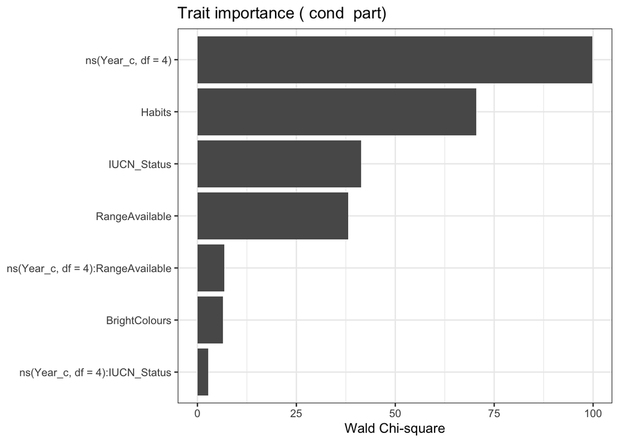

```r
imp$plot
```

```r
ggsave('_results/amph/plots/wald_cond_amph_all.png')
#------
imp <- plot_trait_importance_glmmTMB(m_all, .dat_all,traits = traits_zi,
                                          method = "wald", component = "zi")
imp$table
```

```
  component                           term      Chisq Df            P metric
6        zi ns(Year_c, df = 5):IUCN_Status 43.8614669  5 2.471153e-08  Chisq
4        zi                  BrightColours 37.9312252  1 7.328291e-10  Chisq
5        zi                         Habits 29.6868558  3 1.606039e-06  Chisq
1        zi             ns(Year_c, df = 5) 17.2598046  5 4.032537e-03  Chisq
3        zi                 RangeAvailable 10.5891383  1 1.137540e-03  Chisq
2        zi                    IUCN_Status  0.4033491  1 5.253647e-01  Chisq
```

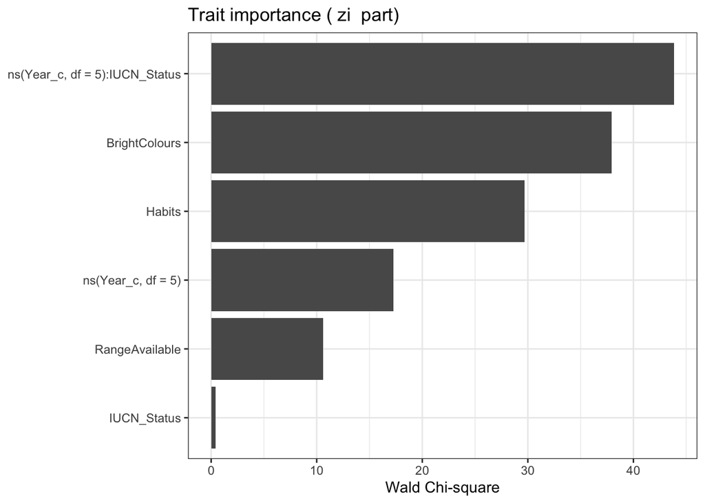

```r
imp$plot
```

```r
ggsave('_results/amph/plots/wald_zi_amph_all.png')
#########################
cat('\n Amphinian_byprod:')
```

```
 Amphinian_byprod:
```

```r
traits_count <- unique(scr_byprod$variable[scr_byprod$keep & scr_byprod$component == 'count'])
traits_zi <- unique(scr_byprod$variable[scr_byprod$keep & scr_byprod$component == 'zero'])

imp <- plot_trait_importance_glmmTMB(m_byprod, .dat_byprod,traits = traits_count,
                                          method = "wald", component = "cond")
imp$table
```

```
  component               term     Chisq Df            P metric
1      cond ns(Year_c, df = 3) 25.129133  3 1.450972e-05  Chisq
2      cond        IUCN_Status  3.830697  1 5.032199e-02  Chisq
```

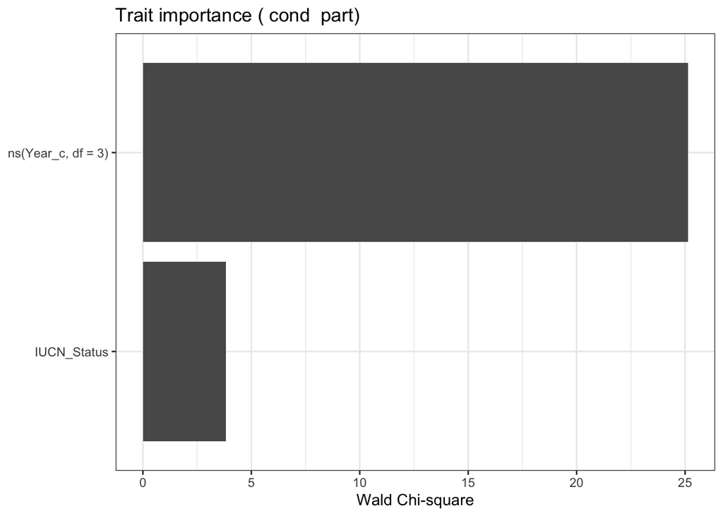

```r
imp$plot
```

```r
ggsave('_results/amph/plots/wald_cond_amph_byprod.png')
#------
imp <- plot_trait_importance_glmmTMB(m_byprod, .dat_byprod,traits = traits_zi,
                                          method = "wald", component = "zi")
imp$table
```

```
  component               term     Chisq Df         P metric
1        zi ns(Year_c, df = 5) 8.0542617  5 0.1532704  Chisq
2        zi        IUCN_Status 0.1069377  1 0.7436579  Chisq
```

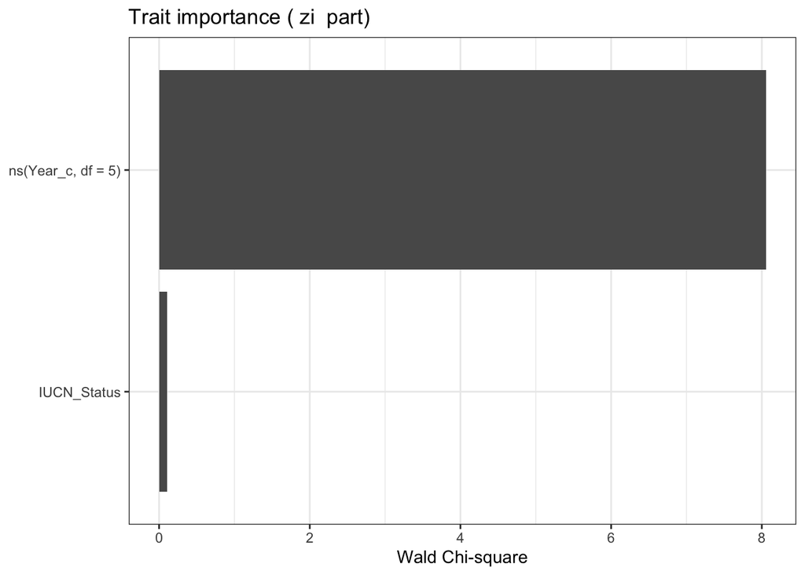

```r
imp$plot
```

```r
ggsave('_results/amph/plots/wald_zi_amph_byprod.png')
#########################
cat('\n Amphinian_live:')
```

```
 Amphinian_live:
```

```r
traits_count <- unique(scr_live$variable[scr_live$keep & scr_live$component == 'count'])
traits_zi <- unique(scr_live$variable[scr_live$keep & scr_live$component == 'zero'])

imp <- plot_trait_importance_glmmTMB(m_live, .dat_live,traits = traits_count,
                                          method = "wald", component = "cond")
imp$table
```

```
  component                              term      Chisq Df            P metric
1      cond                ns(Year_c, df = 4) 114.366211  4 8.520985e-24  Chisq
4      cond                            Habits  70.968064  3 2.648180e-15  Chisq
3      cond                       IUCN_Status  41.062042  1 1.474727e-10  Chisq
2      cond                    RangeAvailable  34.092484  1 5.255388e-09  Chisq
6      cond ns(Year_c, df = 4):RangeAvailable   8.298771  4 8.122696e-02  Chisq
5      cond                     BrightColours   7.603877  1 5.824294e-03  Chisq
7      cond    ns(Year_c, df = 4):IUCN_Status   3.338110  4 5.029168e-01  Chisq
```

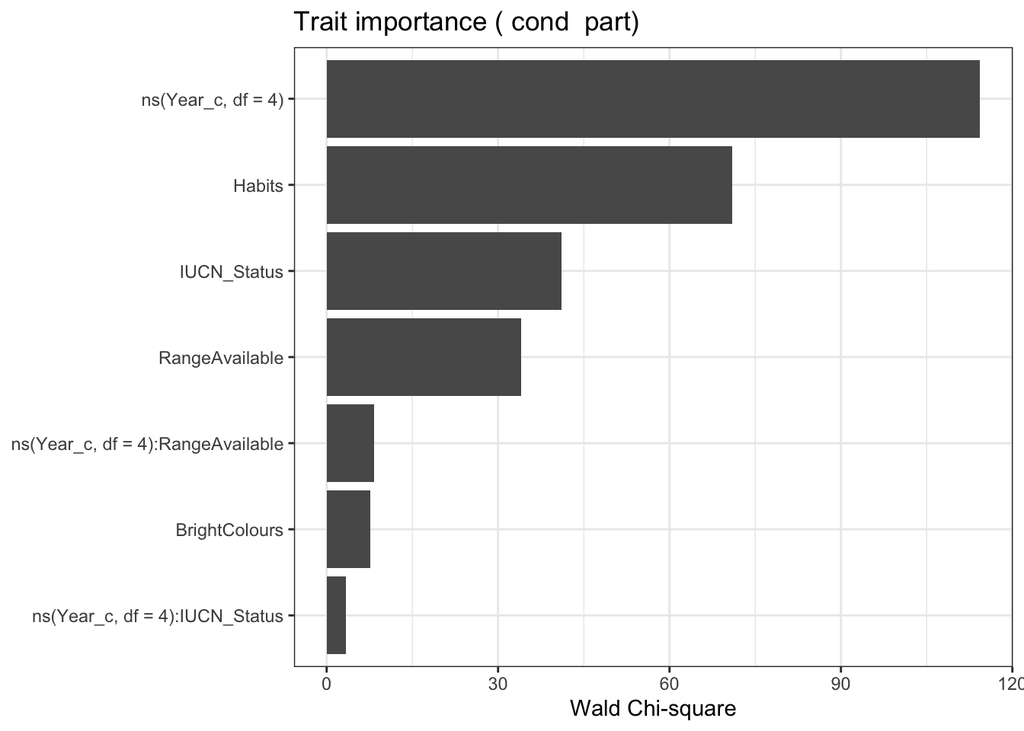

```r
imp$plot
```

```r
ggsave('_results/amph/plots/wald_cond_amph_live.png')
#------
imp <- plot_trait_importance_glmmTMB(m_live, .dat_live,traits = traits_zi,
                                          method = "wald", component = "zi")
imp$table
```

```
  component                              term     Chisq Df            P metric
4        zi                     BrightColours 35.609558  1 2.411016e-09  Chisq
6        zi    ns(Year_c, df = 5):IUCN_Status 27.598715  5 4.359845e-05  Chisq
5        zi                            Habits 26.481303  3 7.561815e-06  Chisq
1        zi                ns(Year_c, df = 5) 13.630176  5 1.813735e-02  Chisq
3        zi                    RangeAvailable 13.183547  1 2.824176e-04  Chisq
7        zi ns(Year_c, df = 5):RangeAvailable  6.774398  5 2.379665e-01  Chisq
2        zi                       IUCN_Status  1.097669  1 2.947783e-01  Chisq
```

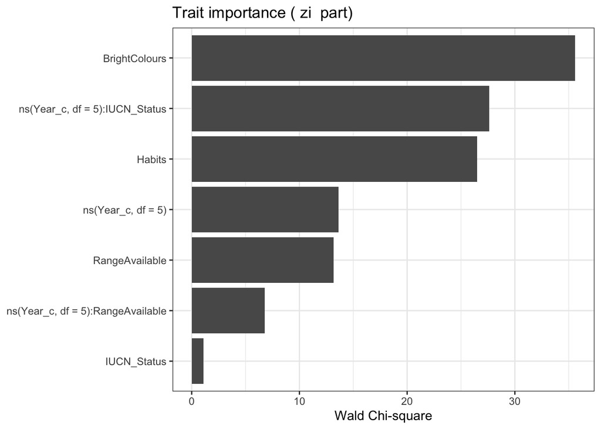

```r
imp$plot
```

```r
ggsave('_results/amph/plots/wald_zi_amph_live.png')
#########################
########################

# AIC test for Cond/Zi parts:
cat('\n Amphinian_all:')
```

```
 Amphinian_all:
```

```r
traits_count <- unique(scr_all$variable[scr_all$keep & scr_all$component == 'count'])
traits_zi <- unique(scr_all$variable[scr_all$keep & scr_all$component == 'zero'])

imp <- plot_trait_importance_glmmTMB(m_all, .dat_all,traits = traits_count,
                                          method = "AIC", component = "cond")
imp$table
```

```
           trait delta_AIC    metric
1 RangeAvailable  18.45510 delta_AIC
2         Habits  41.61382 delta_AIC
3    IUCN_Status  46.35341 delta_AIC
4  BrightColours  95.21498 delta_AIC
```

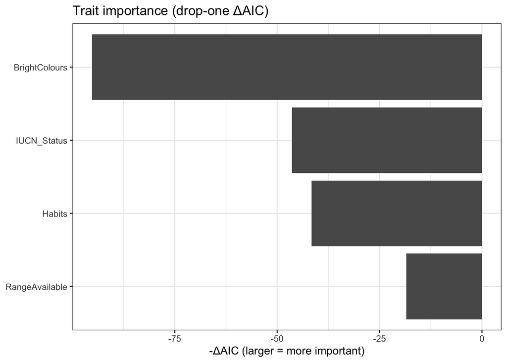

```r
imp$plot
```

```r
ggsave('_results/amph/plots/AIC_cond_amph_all.png')
#------
imp <- plot_trait_importance_glmmTMB(m_all, .dat_all,traits = traits_zi,
                                          method = "AIC", component = "zi")
imp$table
```

```
           trait delta_AIC    metric
1 RangeAvailable  18.45510 delta_AIC
2         Habits  41.61382 delta_AIC
3    IUCN_Status  46.35341 delta_AIC
4  BrightColours  95.21498 delta_AIC
```

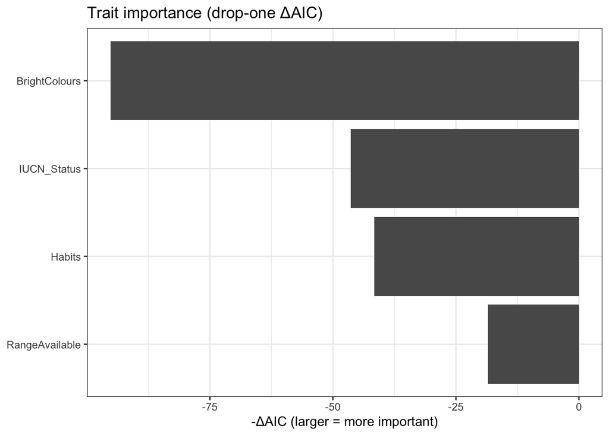

```r
imp$plot
```

```r
ggsave('_results/amph/plots/AIC_zi_amph_all.png')
#########################
cat('\n Amphinian_byprod:')
```

```
 Amphinian_byprod:
```

```r
traits_count <- unique(scr_byprod$variable[scr_byprod$keep & scr_byprod$component == 'count'])
traits_zi <- unique(scr_byprod$variable[scr_byprod$keep & scr_byprod$component == 'zero'])

imp <- plot_trait_importance_glmmTMB(m_byprod, .dat_byprod,traits = traits_count,
                                          method = "AIC", component = "cond")
imp$table
```

```
        trait delta_AIC    metric
1 IUCN_Status  -1.28405 delta_AIC
```

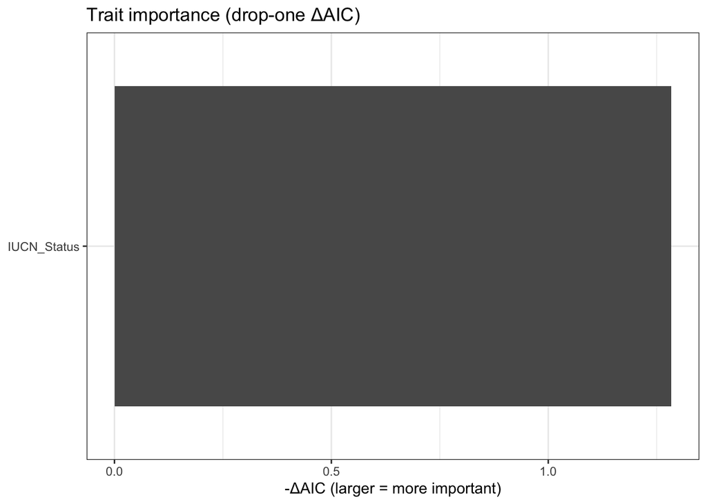

```r
imp$plot
```

```r
ggsave('_results/amph/plots/AIC_cond_amph_byprod.png')
#------
imp <- plot_trait_importance_glmmTMB(m_byprod, .dat_byprod,traits = traits_zi,
                                          method = "AIC", component = "zi")
imp$table
```

```
        trait delta_AIC    metric
1 IUCN_Status  -1.28405 delta_AIC
```

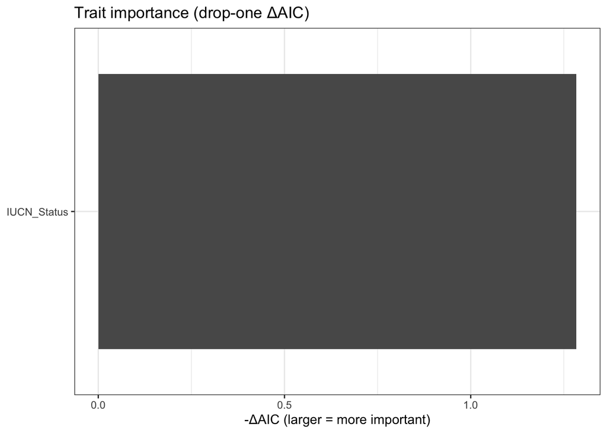

```r
imp$plot
```

```r
ggsave('_results/amph/plots/AIC_zi_amph_byprod.png')
#########################
cat('\n Amphinian_live:')
```

```
 Amphinian_live:
```

```r
traits_count <- unique(scr_live$variable[scr_live$keep & scr_live$component == 'count'])
traits_zi <- unique(scr_live$variable[scr_live$keep & scr_live$component == 'zero'])

imp <- plot_trait_importance_glmmTMB(m_live, .dat_live,traits = traits_count,
                                          method = "AIC", component = "cond")
imp$table
```

```
           trait delta_AIC    metric
1 RangeAvailable  22.82537 delta_AIC
2    IUCN_Status  31.43196 delta_AIC
3         Habits  38.89368 delta_AIC
4  BrightColours  88.73231 delta_AIC
```

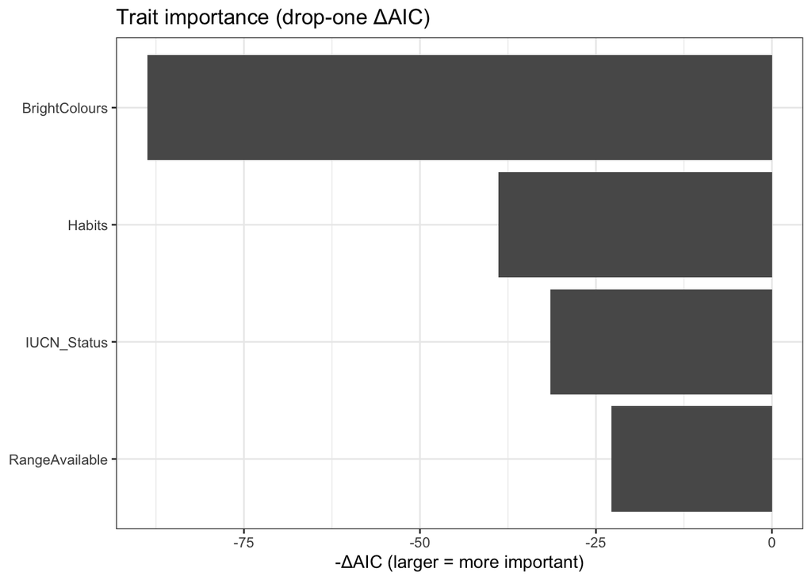

```r
imp$plot
```

```r
ggsave('_results/amph/plots/AIC_cond_amph_live.png')
#------
imp <- plot_trait_importance_glmmTMB(m_live, .dat_live,traits = traits_zi,
                                          method = "AIC", component = "zi")
imp$table
```

```
           trait delta_AIC    metric
1 RangeAvailable  22.82537 delta_AIC
2    IUCN_Status  31.43196 delta_AIC
3         Habits  38.89368 delta_AIC
4  BrightColours  88.73231 delta_AIC
```

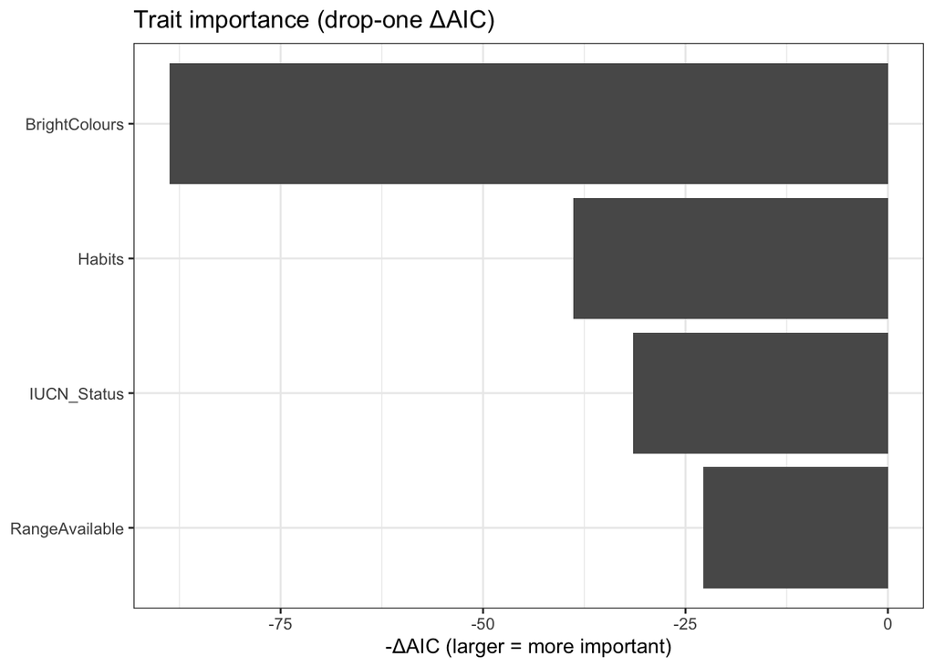

```r
imp$plot
```

```r
ggsave('_results/amph/plots/AIC_zi_amph_live.png')
#########################
########################

cat('\n Amphibians_all:')
```

```
 Amphibians_all:
```

```r
traits <- unique(scr_all$variable[scr_all$keep])

for (n in traits) {
  eff_glmm <- plot_effect_glmmTMB(m_all, .dat_all,trait = n,component = "EY")
  eff_glmm$plot
  ggsave(paste0('_results/amph/plots/effect_amph_all__',n,'.png'))
}
#------
cat('\n Amphibians_byprod:')
```

```
 Amphibians_byprod:
```

```r
traits <- unique(scr_byprod$variable[scr_byprod$keep])

for (n in traits) {
  eff_glmm <- plot_effect_glmmTMB(m_byprod, .dat_byprod,trait = n,component = "EY")
  eff_glmm$plot
  ggsave(paste0('_results/amph/plots/effect_amph_byprod__',n,'.png'))
}
#-----
cat('\n Amphibians_live:')
```

```
 Amphibians_live:
```

```r
traits <- unique(scr_live$variable[scr_live$keep])

for (n in traits) {
  eff_glmm <- plot_effect_glmmTMB(m_live, .dat_live,trait = n,component = "EY")
  eff_glmm$plot
  ggsave(paste0('_results/amph/plots/effect_amph_live__',n,'.png'))
}
#------
```

## Rank Top 10% species in the training data

```r
sp10 <-  rank_species_top(m_all, .dat_all,years=c(2013,2022),top=0.1)

cat('\n Amphibians_all:')
```

```
 Amphibians_all:
```

```r
sp10$Species[sp10$top_flag]
```

```
[1] Scaphiophryne_spinosa Dyscophus_guineti     Mantella_aurantiaca
27 Levels: Agalychnis_lemur Allobates_femoralis ... Telmatobius_culeus
```

```r
write_csv(sp10,'_results/amph/others/rank_species_training_amph_all.csv')


sp10 <-  rank_species_top(m_byprod, .dat_byprod,years=c(2013,2022),top=0.1)
cat('\n Amphibians_byprod:')
```

```
 Amphibians_byprod:
```

```r
sp10$Species[sp10$top_flag]
```

```
[1] Echinotriton_andersoni       Echinotriton_chinhaiensis
[3] Paramesotriton_hongkongensis
27 Levels: Agalychnis_lemur Allobates_femoralis ... Telmatobius_culeus
```

```r
write_csv(sp10,'_results/amph/others/rank_species_training_amph_byprod.csv')




sp10 <-  rank_species_top(m_live, .dat_live,years=c(2013,2022),top=0.1)
cat('\n Amphibians_live:')
```

```
 Amphibians_live:
```

```r
sp10$Species[sp10$top_flag]
```

```
[1] Dyscophus_guineti     Scaphiophryne_spinosa Mantella_aurantiaca
27 Levels: Agalychnis_lemur Allobates_femoralis ... Telmatobius_culeus
```

```r
write_csv(sp10,'_results/amph/others/rank_species_training_amph_live.csv')
```

## Predict for NEW species

Here, we used the model fitted for amphibians_all, to predict the expected trade for new species:

```r
amph <- read.csv('../outputs/tables/pred_dat_amph.csv')


top.new.phy <- predict_hurdle_new_species_phylo(m_all,.dat_all,newdata = amph,
                                                years = 2013:2022,phy_full = phy,
                                                top = 0.1,
                                                summary = 'mean',metric = 'EY')

# saving as a CSV:
write_csv(top.new.phy$top,'_results/amph/others/rank_new_species.csv')


# looking at the head of the table:
head(top.new.phy$top[top.new.phy$top$top_flag,],10)
```

```
# A tibble: 10 × 7
   Species                   n_year p_trade  EY_FE EY_phylo  rank top_flag
   <chr>                      <int>   <dbl>  <dbl>    <dbl> <int> <lgl>
 1 Oreophryne_minuta             10   0.828 15285.   15285.     1 TRUE
 2 Philautus_saueri              10   0.807 11542.   11542.     2 TRUE
 3 Heterixalus_tricolor          10   0.802 10846.   10846.     3 TRUE
 4 Ranitomeya_defleri            10   0.799 10473.   10473.     4 TRUE
 5 Ansonia_penangensis           10   0.791  9431.    9431.     5 TRUE
 6 Microhyla_borneensis          10   0.802  6434.    6434.     6 TRUE
 7 Nymphargus_oreonympha         10   0.753  5922.    5922.     7 TRUE
 8 Cochranella_geijskesi         10   0.748  5615.    5615.     8 TRUE
 9 Hyperolius_veithi             10   0.790  5517.    5517.     9 TRUE
10 Tachycnemis_seychellensis     10   0.746  5504.    5504.    10 TRUE
```

```r
###########
```

## Modelling Using Bayesian approach

Let’s train the models using Bayesian approach (brms) but based on screening results prepared in the previous section:

```r
#### KEEP IN MIND that the priors assumed scaling/log of the numeric variables,
# in case if some variables are not scaled, make sure the right priors are used;
.prior <- c(brms::prior(normal(0, 2), class = "Intercept"),
            brms::prior(normal(0, 1), class = "b"),
            brms::prior(normal(0, 2), class = "Intercept", dpar = "hu"),
            brms::prior(normal(0, 1), class = "b", dpar = "hu"),
            brms::prior(student_t(3, 0, 1), class = "sd"),
            brms::prior(gamma(2, 0.2), class = "shape")
            )

if (!file.exists('_results/amph/models/model_brms_amph_all.rds') || .model_update) {
  m2_all <- fit_hurdle_brms(.dat_all, scr_all,prior = .prior, phylo_in = "count",backend='cmdstanr')
  saveRDS(m2_all,'_results/amph/models/model_brms_amph_all.rds')
  cat('\n Bayesian Model for amph_all is saved...!')
} else {
  m2_all <- readRDS('_results/amph/models/model_brms_amph_all.rds')
}
#-----
if (!file.exists('_results/amph/models/model_brms_amph_byprod.rds') || .model_update) {
  m2_byprod <- fit_hurdle_brms(.dat_byprod, scr_byprod,prior = .prior, phylo_in = "count",backend='cmdstanr')
  saveRDS(m2_byprod,'_results/amph/models/model_brms_amph_byprod.rds')
  cat('\n Bayesian Model for amph_byprod is saved...!')
} else {
  m2_byprod <- readRDS('_results/amph/models/model_brms_amph_byprod.rds')
}
#-----
if (!file.exists('_results/amph/models/model_brms_amph_live.rds') || .model_update) {
  m2_live <- fit_hurdle_brms(.dat_live, scr_all,prior = .prior, phylo_in = "count",backend='cmdstanr')
  saveRDS(m2_all,'_results/amph/models/model_brms_amph_live.rds')
  cat('\n Bayesian Model for amph_live is saved...!')
} else {
  m2_live <- readRDS('_results/amph/models/model_brms_amph_live.rds')
}
#-----
#----
```

## Peformance and Summary of Bayesian Models

Loo, and model summary:

```r
cat('\n Amphibans_all:')
```

```
 Amphibans_all:
```

```r
# LOO:
brms::loo(m2_all) # you may add moment_match = TRUE if you get bad/very bad values
```

```
Computed from 12000 by 528 log-likelihood matrix.

         Estimate    SE
elpd_loo  -1206.5  81.9
p_loo        28.8   5.6
looic      2412.9 163.9
------
MCSE of elpd_loo is NA.
MCSE and ESS estimates assume MCMC draws (r_eff in [0.9, 1.6]).

Pareto k diagnostic values:
                         Count Pct.    Min. ESS
(-Inf, 0.7]   (good)     527   99.8%   767
   (0.7, 1]   (bad)        0    0.0%   <NA>
   (1, Inf)   (very bad)   1    0.2%   <NA>
See help('pareto-k-diagnostic') for details.
```

```r
# Summary:
summary(m2_all)
```

```
 Family: hurdle_negbinomial
  Links: mu = log; shape = identity; hu = logit
Formula: Trade ~ 1 + ns(Year_c, df = 4) + RangeAvailable + IUCN_Status + Habits + BrightColours + ns(Year_c, df = 4):RangeAvailable + ns(Year_c, df = 4):IUCN_Status + (1 | gr(Species, cov = A))
         hu ~ 1 + ns(Year_c, df = 5) + IUCN_Status + RangeAvailable + BrightColours + Habits + ns(Year_c, df = 5):IUCN_Status + ns(Year_c, df = 5):RangeAvailable
   Data: dat (Number of observations: 528)
  Draws: 4 chains, each with iter = 4000; warmup = 1000; thin = 1;
         total post-warmup draws = 12000

Multilevel Hyperparameters:
~Species (Number of levels: 27)
              Estimate Est.Error l-95% CI u-95% CI Rhat Bulk_ESS Tail_ESS
sd(Intercept)     1.39      0.48     0.67     2.53 1.00     4742     6989

Regression Coefficients:
                                        Estimate Est.Error l-95% CI u-95% CI
Intercept                                   3.80      1.37     1.00     6.44
hu_Intercept                                5.81      0.74     4.43     7.29
nsYear_cdfEQ41                              1.19      0.72    -0.23     2.58
nsYear_cdfEQ42                             -0.20      0.62    -1.40     1.00
nsYear_cdfEQ43                             -0.21      0.93    -2.10     1.60
nsYear_cdfEQ44                             -0.83      0.59    -1.97     0.33
RangeAvailable                             -0.54      0.52    -1.54     0.49
IUCN_StatusThreatened                      -0.33      0.65    -1.58     0.94
HabitsTer                                  -0.92      0.84    -2.53     0.79
HabitsTerAq                                 0.12      0.62    -1.11     1.33
HabitsTerArb                                0.66      0.69    -0.71     2.00
BrightColoursYes                            0.95      0.75    -0.55     2.36
nsYear_cdfEQ41:RangeAvailable               1.07      0.62    -0.16     2.27
nsYear_cdfEQ42:RangeAvailable               0.51      0.56    -0.58     1.59
nsYear_cdfEQ43:RangeAvailable              -1.17      0.88    -2.87     0.57
nsYear_cdfEQ44:RangeAvailable               1.32      0.54     0.28     2.36
nsYear_cdfEQ41:IUCN_StatusThreatened        0.51      0.83    -1.11     2.16
nsYear_cdfEQ42:IUCN_StatusThreatened       -1.13      0.76    -2.61     0.38
nsYear_cdfEQ43:IUCN_StatusThreatened        0.19      0.93    -1.63     1.98
nsYear_cdfEQ44:IUCN_StatusThreatened       -0.76      0.78    -2.29     0.75
hu_nsYear_cdfEQ51                          -0.66      0.64    -1.92     0.61
hu_nsYear_cdfEQ52                           0.24      0.66    -1.04     1.53
hu_nsYear_cdfEQ53                          -2.46      0.58    -3.58    -1.33
hu_nsYear_cdfEQ54                          -0.27      0.83    -1.91     1.32
hu_nsYear_cdfEQ55                          -1.29      0.57    -2.41    -0.18
```

[output cut: 51 more lines]

```
hu_nsYear_cdfEQ54:IUCN_StatusThreatened 1.00    16371     9437
hu_nsYear_cdfEQ55:IUCN_StatusThreatened 1.00    13127     9715
hu_nsYear_cdfEQ51:RangeAvailable        1.00    12565     9194
hu_nsYear_cdfEQ52:RangeAvailable        1.00    14530     9449
hu_nsYear_cdfEQ53:RangeAvailable        1.00    13063     9163
hu_nsYear_cdfEQ54:RangeAvailable        1.00    12212     9764
hu_nsYear_cdfEQ55:RangeAvailable        1.00    15237     9166

Further Distributional Parameters:
      Estimate Est.Error l-95% CI u-95% CI Rhat Bulk_ESS Tail_ESS
shape     0.93      0.11     0.72     1.16 1.00    14651     9188

Draws were sampled using sample(hmc). For each parameter, Bulk_ESS
and Tail_ESS are effective sample size measures, and Rhat is the potential
scale reduction factor on split chains (at convergence, Rhat = 1).
```

```r
#-------

cat('\n Amphibans_byprod:')
```

```
 Amphibans_byprod:
```

```r
# LOO:
brms::loo(m2_byprod) # you may add moment_match = TRUE if you get bad/very bad values
```

```
Computed from 12000 by 528 log-likelihood matrix.

         Estimate   SE
elpd_loo    -94.0 30.4
p_loo         7.3  2.9
looic       187.9 60.9
------
MCSE of elpd_loo is NA.
MCSE and ESS estimates assume MCMC draws (r_eff in [0.6, 1.9]).

Pareto k diagnostic values:
                         Count Pct.    Min. ESS
(-Inf, 0.7]   (good)     526   99.6%   1281
   (0.7, 1]   (bad)        2    0.4%   <NA>
   (1, Inf)   (very bad)   0    0.0%   <NA>
See help('pareto-k-diagnostic') for details.
```

```r
# Summary:
summary(m2_byprod)
```

```
 Family: hurdle_negbinomial
  Links: mu = log; shape = identity; hu = logit
Formula: Trade ~ 1 + ns(Year_c, df = 3) + IUCN_Status + (1 | gr(Species, cov = A))
         hu ~ 1 + ns(Year_c, df = 5) + IUCN_Status
   Data: dat (Number of observations: 528)
  Draws: 4 chains, each with iter = 4000; warmup = 1000; thin = 1;
         total post-warmup draws = 12000

Multilevel Hyperparameters:
~Species (Number of levels: 27)
              Estimate Est.Error l-95% CI u-95% CI Rhat Bulk_ESS Tail_ESS
sd(Intercept)     2.20      1.35     0.21     5.43 1.00     3002     2768

Regression Coefficients:
                         Estimate Est.Error l-95% CI u-95% CI Rhat Bulk_ESS
Intercept                    3.20      1.65    -0.42     6.04 1.00     5850
hu_Intercept                 4.45      0.62     3.28     5.72 1.00    15217
nsYear_cdfEQ31              -0.13      1.00    -2.10     1.85 1.00    19387
nsYear_cdfEQ32               0.19      0.99    -1.77     2.09 1.00    18243
nsYear_cdfEQ33              -0.34      1.00    -2.25     1.63 1.00    13303
IUCN_StatusThreatened        0.19      0.95    -1.69     2.05 1.00    11907
hu_nsYear_cdfEQ51           -0.85      0.83    -2.45     0.80 1.00    17025
hu_nsYear_cdfEQ52            0.32      0.86    -1.36     2.03 1.00    16951
hu_nsYear_cdfEQ53            0.24      0.84    -1.38     1.92 1.00    17711
hu_nsYear_cdfEQ54           -0.18      0.93    -2.02     1.62 1.00    18770
hu_nsYear_cdfEQ55            0.74      0.86    -0.90     2.45 1.00    18955
hu_IUCN_StatusThreatened    -0.03      0.57    -1.15     1.08 1.00    17777
                         Tail_ESS
Intercept                    6886
hu_Intercept                 8113
nsYear_cdfEQ31               8985
nsYear_cdfEQ32               9219
nsYear_cdfEQ33               8573
IUCN_StatusThreatened        8761
hu_nsYear_cdfEQ51            9210
hu_nsYear_cdfEQ52            9143
hu_nsYear_cdfEQ53            9541
hu_nsYear_cdfEQ54            8780
hu_nsYear_cdfEQ55            8563
hu_IUCN_StatusThreatened     9407

Further Distributional Parameters:
      Estimate Est.Error l-95% CI u-95% CI Rhat Bulk_ESS Tail_ESS
shape     0.51      0.33     0.06     1.32 1.00     4752     4527

Draws were sampled using sample(hmc). For each parameter, Bulk_ESS
and Tail_ESS are effective sample size measures, and Rhat is the potential
scale reduction factor on split chains (at convergence, Rhat = 1).
```

```r
#------
cat('\n Amphibans_live:')
```

```
 Amphibans_live:
```

```r
# LOO:
brms::loo(m2_live) # you may add moment_match = TRUE if you get bad/very bad values
```

```
Computed from 12000 by 528 log-likelihood matrix.

         Estimate    SE
elpd_loo  -1206.5  81.9
p_loo        28.8   5.6
looic      2412.9 163.9
------
MCSE of elpd_loo is NA.
MCSE and ESS estimates assume MCMC draws (r_eff in [0.9, 1.6]).

Pareto k diagnostic values:
                         Count Pct.    Min. ESS
(-Inf, 0.7]   (good)     527   99.8%   767
   (0.7, 1]   (bad)        0    0.0%   <NA>
   (1, Inf)   (very bad)   1    0.2%   <NA>
See help('pareto-k-diagnostic') for details.
```

```r
# Summary:
summary(m2_live)
```

```
 Family: hurdle_negbinomial
  Links: mu = log; shape = identity; hu = logit
Formula: Trade ~ 1 + ns(Year_c, df = 4) + RangeAvailable + IUCN_Status + Habits + BrightColours + ns(Year_c, df = 4):RangeAvailable + ns(Year_c, df = 4):IUCN_Status + (1 | gr(Species, cov = A))
         hu ~ 1 + ns(Year_c, df = 5) + IUCN_Status + RangeAvailable + BrightColours + Habits + ns(Year_c, df = 5):IUCN_Status + ns(Year_c, df = 5):RangeAvailable
   Data: dat (Number of observations: 528)
  Draws: 4 chains, each with iter = 4000; warmup = 1000; thin = 1;
         total post-warmup draws = 12000

Multilevel Hyperparameters:
~Species (Number of levels: 27)
              Estimate Est.Error l-95% CI u-95% CI Rhat Bulk_ESS Tail_ESS
sd(Intercept)     1.39      0.48     0.67     2.53 1.00     4742     6989

Regression Coefficients:
                                        Estimate Est.Error l-95% CI u-95% CI
Intercept                                   3.80      1.37     1.00     6.44
hu_Intercept                                5.81      0.74     4.43     7.29
nsYear_cdfEQ41                              1.19      0.72    -0.23     2.58
nsYear_cdfEQ42                             -0.20      0.62    -1.40     1.00
nsYear_cdfEQ43                             -0.21      0.93    -2.10     1.60
nsYear_cdfEQ44                             -0.83      0.59    -1.97     0.33
RangeAvailable                             -0.54      0.52    -1.54     0.49
IUCN_StatusThreatened                      -0.33      0.65    -1.58     0.94
HabitsTer                                  -0.92      0.84    -2.53     0.79
HabitsTerAq                                 0.12      0.62    -1.11     1.33
HabitsTerArb                                0.66      0.69    -0.71     2.00
BrightColoursYes                            0.95      0.75    -0.55     2.36
nsYear_cdfEQ41:RangeAvailable               1.07      0.62    -0.16     2.27
nsYear_cdfEQ42:RangeAvailable               0.51      0.56    -0.58     1.59
nsYear_cdfEQ43:RangeAvailable              -1.17      0.88    -2.87     0.57
nsYear_cdfEQ44:RangeAvailable               1.32      0.54     0.28     2.36
nsYear_cdfEQ41:IUCN_StatusThreatened        0.51      0.83    -1.11     2.16
nsYear_cdfEQ42:IUCN_StatusThreatened       -1.13      0.76    -2.61     0.38
nsYear_cdfEQ43:IUCN_StatusThreatened        0.19      0.93    -1.63     1.98
nsYear_cdfEQ44:IUCN_StatusThreatened       -0.76      0.78    -2.29     0.75
hu_nsYear_cdfEQ51                          -0.66      0.64    -1.92     0.61
hu_nsYear_cdfEQ52                           0.24      0.66    -1.04     1.53
hu_nsYear_cdfEQ53                          -2.46      0.58    -3.58    -1.33
hu_nsYear_cdfEQ54                          -0.27      0.83    -1.91     1.32
hu_nsYear_cdfEQ55                          -1.29      0.57    -2.41    -0.18
```

[output cut: 51 more lines]

```
hu_nsYear_cdfEQ54:IUCN_StatusThreatened 1.00    16371     9437
hu_nsYear_cdfEQ55:IUCN_StatusThreatened 1.00    13127     9715
hu_nsYear_cdfEQ51:RangeAvailable        1.00    12565     9194
hu_nsYear_cdfEQ52:RangeAvailable        1.00    14530     9449
hu_nsYear_cdfEQ53:RangeAvailable        1.00    13063     9163
hu_nsYear_cdfEQ54:RangeAvailable        1.00    12212     9764
hu_nsYear_cdfEQ55:RangeAvailable        1.00    15237     9166

Further Distributional Parameters:
      Estimate Est.Error l-95% CI u-95% CI Rhat Bulk_ESS Tail_ESS
shape     0.93      0.11     0.72     1.16 1.00    14651     9188

Draws were sampled using sample(hmc). For each parameter, Bulk_ESS
and Tail_ESS are effective sample size measures, and Rhat is the potential
scale reduction factor on split chains (at convergence, Rhat = 1).
```

## Plot the effect based on Bayesian models

Plot the effects for each trait and dataset based on the models trained with brms:

```r
cat('\n Amphibians_all:')
```

```
 Amphibians_all:
```

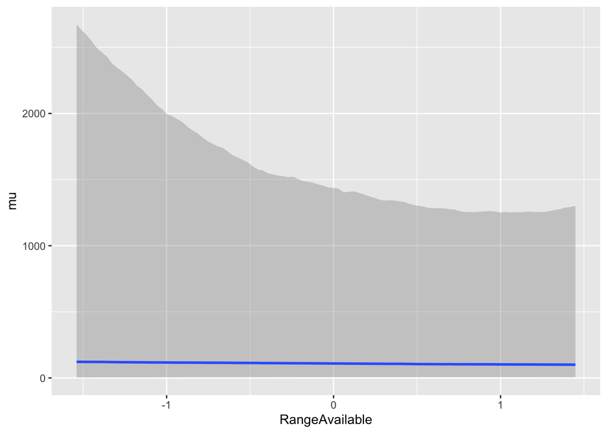

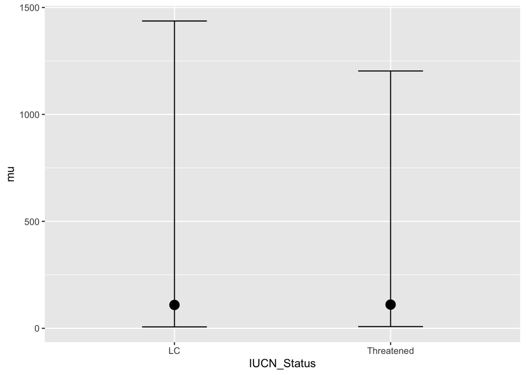

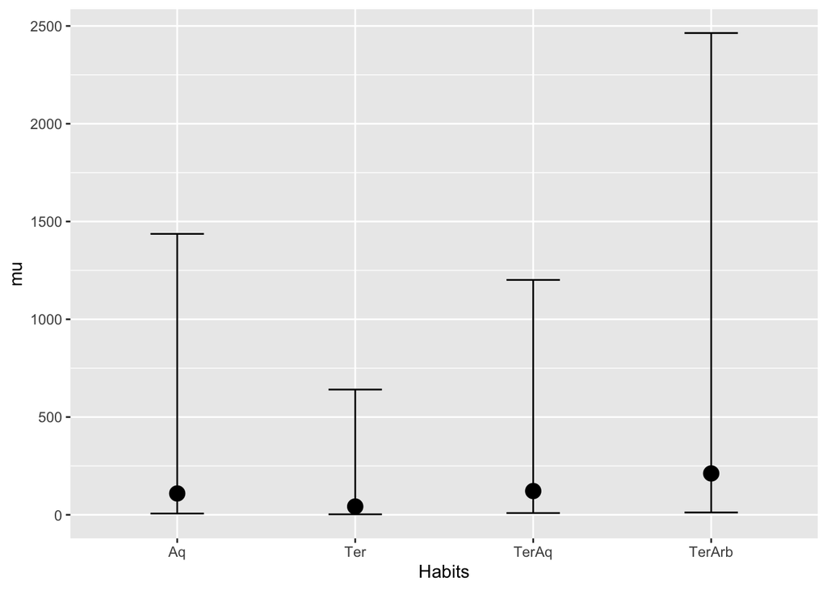

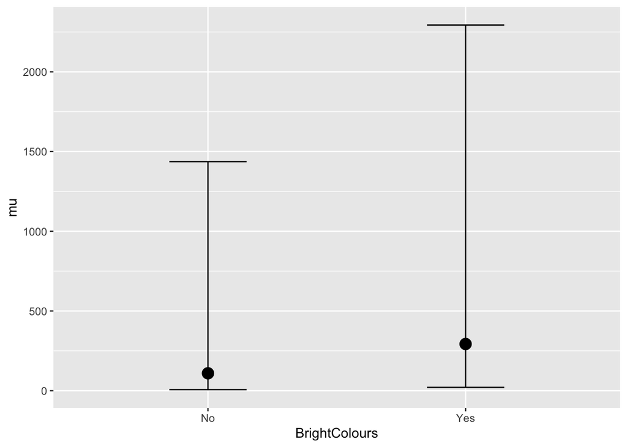

```r
traits_count <- unique(scr_all$variable[scr_all$keep & scr_all$component == 'count'])
traits_zi <- unique(scr_all$variable[scr_all$keep & scr_all$component == 'zero'])


for (n in traits_count) {
  eff_range_mu <- plot_effect_brms(m2_all, n, component = "mu")
  eff_range_mu$plot
  ggsave(paste0('_results/amph/plots/effect_brms_mu_amph_all__',n,'.png'))
  eff_range_mu$ce
}
```

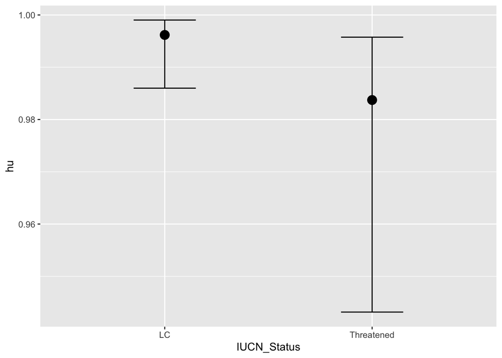

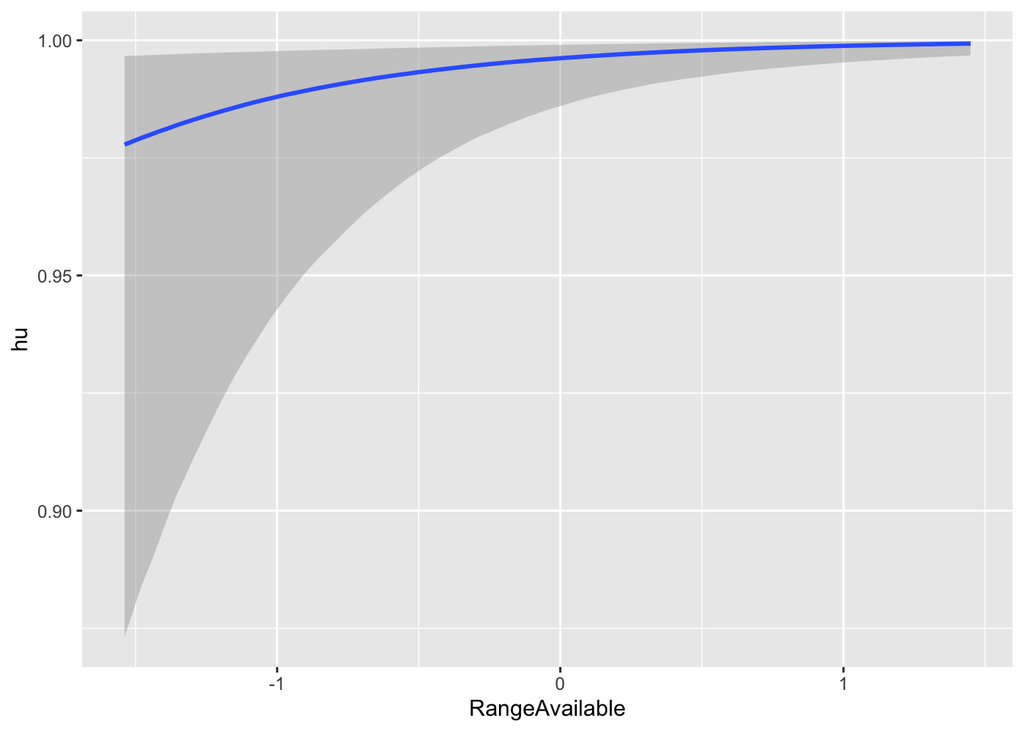

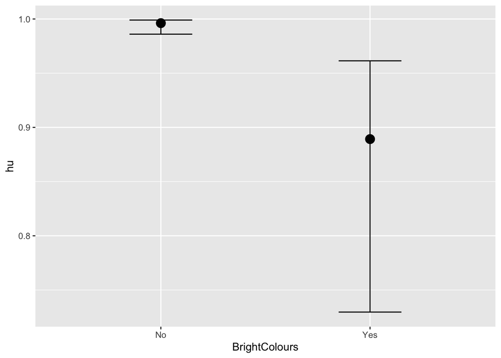

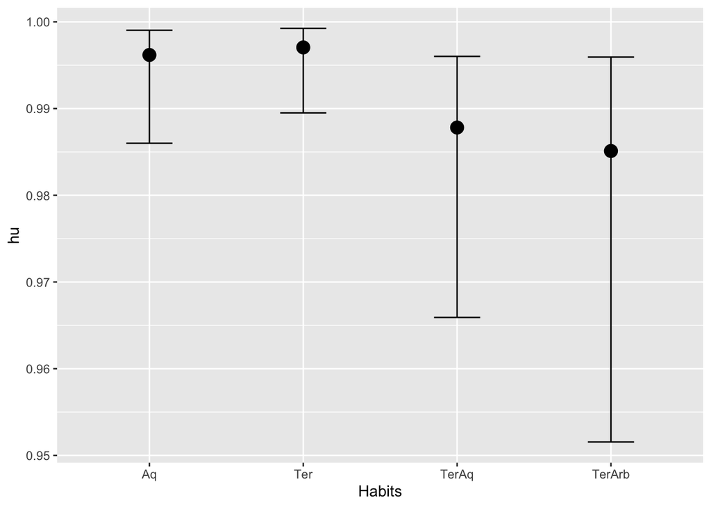

```r
#---
for (n in traits_zi) {
  eff_range_mu <- plot_effect_brms(m2_all, n, component = "hu")
  eff_range_mu$plot
  ggsave(paste0('_results/amph/plots/effect_brms_hu_amph_all__',n,'.png'))
  eff_range_mu$ce
}
```